# Bayesian Regression with Regularizing Priors

```r
library(ggplot2)
library(tidyr)
#install.packages('rmutil')
library(rmutil)
library(dplyr)
```

One of the nice things about Bayesian statistics is that it provides a mathematically neat framework for a lot of concepts that are often taught separately. Today we'll look at regression, and how the priors placed on the coefficient vector can recapitulate various regularization schemes.

The setup of the problem is that we have $m$ independent observations $(\mathbf{x}_i, y_i)$ where $\mathbf{x}_i \in \mathbb{R}^k$ and $y_i \in \mathbb{R}$. We'll kit this out as a $X$ a $m\times k$ matrix and $Y$ a $m \times 1$ matrix. $\beta$, the vector of coefficients is then a $1 \times k$ column vector. We'll assume gaussian errors and the $\mathbf{x}_i$ as exogenous and so the likelihood is then $y_i \sim \mathcal{N}(\mathbf{x}_i \beta, \sigma)$

When we are relating frequentist estimators to their bayesian analogs, often it is true that if the estimator is the maximum likelihood estimator under a specific likelihood, than that of course corresponds to a bayesian model with the same likelihood and a noninfomative prior (as in that case, the posterior distribution should simply be the likelihood).

That is the case here: under homoskedasticity and independent gaussian error, OLS is the MLE, and as we can see, under the improper prior where $\mathrm{p}(\beta) \propto 1$, the OLS estimator is the mode of the posterior distribution.

This follows from (where else?) bayes rule: $$\mathrm{p}(\beta | Y) \propto \mathrm{p}(Y|X\beta) \mathrm{p}(\beta) \propto \prod_{i=0}^{i=m} f(y_i | x_i\beta) \cdot 1$$ where the $f$ is the gaussian pdf $$f(x | \mathbf{x}_i \beta) = \frac{1}{\sqrt{2\pi\sigma^2}}\mathrm{exp}(\frac{(y_i - \mathbf{x}_i \beta)^2}{2\sigma^2})$$

Taking then the log-likelihood, we see that $\mathrm{log}(\mathrm{p}(\beta| Y)) \propto \sum_{i=0}^{i=m} (y_i - \mathrm{x}_i\beta)^2 $ which is precisely the quantity minimized in OLS. As $x^2$ is a convex function and convex functions are closed under addition, then the negative log-likelihood has a unique global minimum $\beta$, which is the point estimate from the OLS estimator. As above $f(y_i | \mathrm{x}_i \beta)$ is the posterior, and as negative log is a convex function and so the maximizing $\beta$ also serves as the point of highest density in the posterior.

When we consider replacing the prior on $\beta$ with a multivariate normal distribution $\beta \sim \mathcal{N}(0, \lambda^{-1} I)$, constraining the coefficient vector to be close to zero overall, with strength related to the prior variance. This produces a point estimate that is equal to ridge regression: $$ log (p(\beta | y_i)) \propto \sum_{i=1}^{i=m} (y_i - \mathrm{x}_i \beta)^2 + \lambda \lvert \rvert \mathrm{x}_i \lvert \rvert_2$$

Similarly, if the prior is set to be multivariate Laplacian distribution with location $0$ and scale $\eta^{-1}I$, with density $$\mathrm{p}(\beta) = \frac{\eta}{2} \mathrm{exp}(-\eta\lvert\rvert x \rvert\lvert_1)$$ and so we see immediately that $$\mathrm{log}\mathrm{p}(\beta|Y) \propto \sum_{i=1}^{i=m}(y_i - \mathrm{x_i}\beta)^2 + \eta \lvert \rvert x \lvert \rvert_1 $$ which serves as ${l}_1$ regularization ala LASSO

What nicely jumps out, is that elastic net, which has both a $l_2$ and $l_1$ regularization term, follows from having prior density distribution of the product of a $\mathrm{Laplace}(0, \eta^{-1}I)$ and a $\mathcal{N}(0, \lambda^{-1}I)$ distribution

In both of these cases, we treat "noise" coefficients (those who's 'true value' is zero) and "signal" coefficients (those whose true values are much decently far away from zero), symmetrically. We might instead have a prior belief that could correspond to the statement that we believe a certain fraction of the coefficients are exactly zero, and for the others we have a priori no information. This believe corresponds to the spike-and-slab distribution, in which a positive point probability is placed on zero (the "spike"), and an uniform or normal with very large variance suffices as the prior distribution for the rest of the real line (the "slab").

While the spike-and-slab has excellent properties, it is difficult to implement computationally. Instead, if we want to stay in the realm of continuous regularizing prior distributions, like the normal or laplacian, we can use the Horseshoe prior, which gives similar results to spike and slab but is easier to sample from.

Let the horseshoe distribution $\pi_{HS}$ assumes that each $\beta_i$ is conditionally independent given the one parameter $\tau$ which controls the *global* shrinkage of all the coefficients. The density breaks out into two parts: $\lambda_i$ which controls the *local* shrinkage of the given parameter, and the distribution for $beta_i$ which is normal with scale depending on $\lambda_i$ and $\tau$.

In symbols, $\pi_{HS}(\beta)$ follows from: $$\lambda_i \sim \mathrm{Cauchy}^+(0, 1) $$ $$\beta_i \sim \mathcal{N}(0, \lambda_i^2 \tau^2)$$

That is, for a given set of $\mathbf{\lambda^2} = [\lambda_1^2, \ldots, \lambda_m^2]$, the distribution of the coefficients is $\mathcal{N}(0, \mathbf{\lambda^2} \tau^2 I)$ and so is ellipsodal.

This distribution $\pi_{HS}(\beta | \tau) $ doesn't have a closed form representation, but has two notable traits: an infinite spike at zero, and very flat tails. Roughly, it looks like $\log(1 + 2/\beta_i^2)$

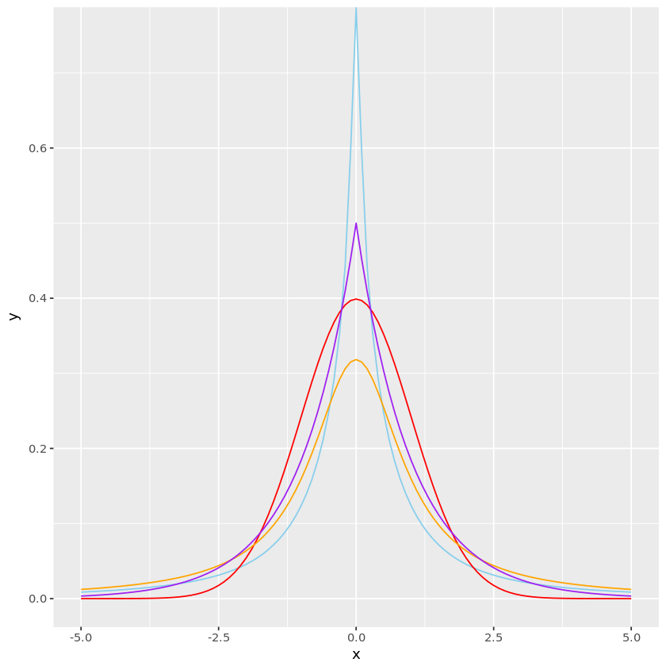

```r
library(ggplot2)
approx_HS <- function(x) log(1 + 2/x^2)/(2 * sqrt(2) * pi ) # 1/(2sqrt(2)*pi) is normalizing factor
print(ggplot(data.frame(x = 0), aes(x=x)) +
      stat_function(fun = approx_HS, color = 'skyblue') +
      stat_function(fun = dnorm, args= c('mean' = 0, 'sd' = 1), color = 'red') +
      stat_function(fun = dcauchy, args = c('location' = 0, 'scale' = 1), color = 'orange') +
      stat_function(fun= dlaplace, args = c('m' = 0, 's' = 1), color = 'purple') +
      xlim(-5, 5) +
      ylim(0, 0.75))
```

Moving to the log density makes the difference in asymptotic behavior more stark

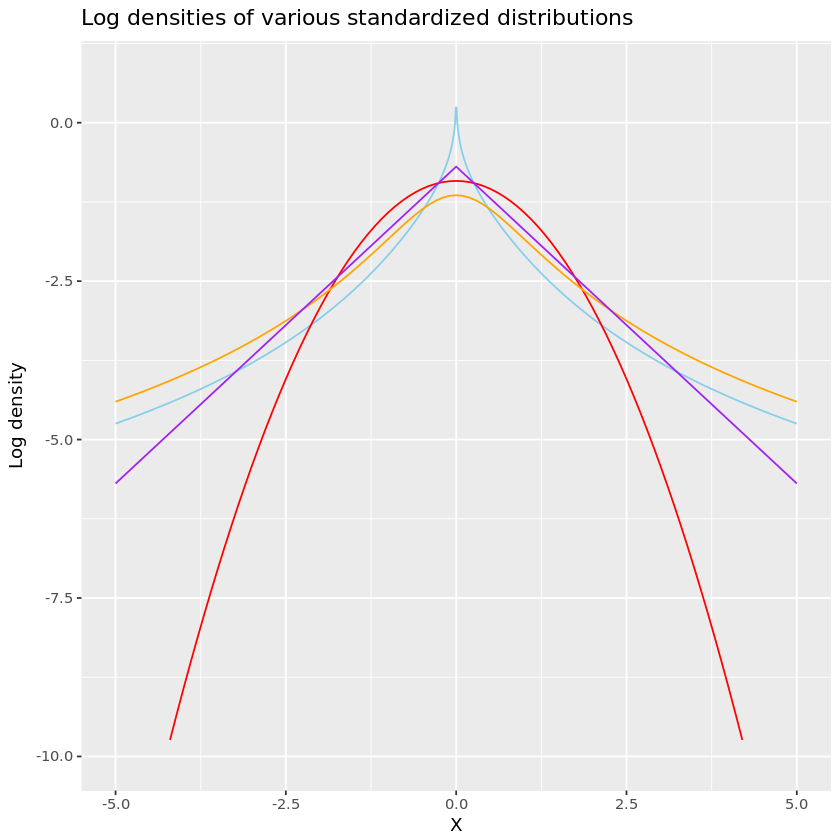

```r
logapprox_HS <- function(x) log(log(1 + 2/x^2)/(2 * sqrt(2) * pi))
logdnorm <- function (x) log(dnorm(x, mean = 0, sd = 1))
logdcauchy <- function(x) log(dcauchy(x, location = 0, scale = 1))
logdlaplace <- function(x) log(dlaplace(x, m = 0, s = 1))
print(ggplot(data.frame(x = 0), aes(x=x)) +
      stat_function(fun = logapprox_HS, color = 'skyblue', n = 1000) +
      stat_function(fun = logdnorm, color = 'red')  +
      stat_function(fun = logdcauchy, color = 'orange') +
      stat_function(fun = logdlaplace, color = 'purple') +
      xlim(-5, 5) +
      ylim(-10, 0.75) +
    labs(x = 'X', y = 'Log density', title = 'Log densities of various standardized distributions'))
```

Essentially, the distribution consists of a mixture of normal distributions with different scales. Nicely, this allows us to compare the horseshoe more easily to the other regularizing priors that we looked at, as by shifting the distribution of the $\lambda_i$, we can recover the other distributions (as the both the normal and laplacian are of the exponential family, which is a subset of the scale-mixture family).

We can then define a quantity that measures to what extent the coefficients are shrunk towards zero, by measuring the amount of posterior probability that is from zero to the maximum likelihood point estimate.

If we let $\kappa = \frac{1}{1 + \lambda_i^2}$ , then as both the likelihood and prior are gaussian, if we update the posterior with one data point, the mean $E(\beta_i | y_i, \lambda_i^2) = \frac{\lambda_i^2 (y_i/x_i) + 0}{\lambda_i^2 + 1} = (1 - \kappa_i) y_i/x_i$ where $y_i/x_i$ is the most likely estimate for $\beta_i$ based on the one data point. (This breaks down if $x_i$ were zero, but in that case each $\beta_i$ is equally likely and so the posterior is the prior.)

Therefore, when $\kappa_i$ is close to zero, the coefficient estimate is unshrunk, and when it is close to 1, the coefficient estimate is shrunk to zero. This then allows us to compare the "shrinkage profiles" of these various priors, by looking at the prior distribution of $kappa_i$

```r
lambda2_laplace <- rexp(100000, rate = 1/2)
lambda2_normal <- rexp(100000, rate = 1)
lambda_horseshoe <- rcauchy(100000)
```

```r
k_laplace <- 1/(1+lambda2_laplace)
k_normal <- 1/(1 + lambda2_normal)
k_horseshoe <- 1/(1+ lambda_horseshoe^2)
df <- data.frame(k_laplace = k_laplace, k_normal = k_normal, k_horseshoe = k_horseshoe)
df <- df %>% gather(k, value, k_laplace:k_horseshoe)
```

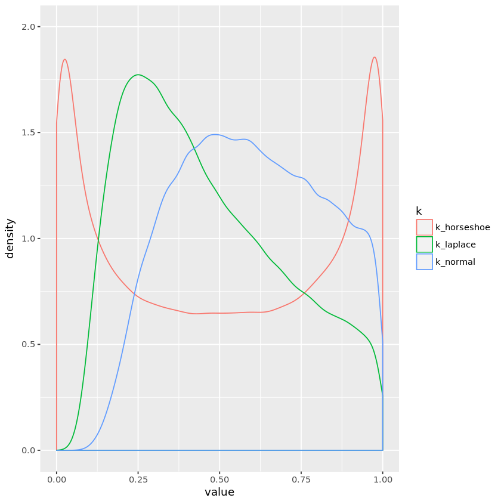

```r
ggplot(df, aes(color = k, x = value)) + geom_density() + xlim(0, 1) + ylim(0, 2)
```

However, completely unregularized "signal" coefficients may not be what we want, and in many corner cases, a bit of regularization prevents the posterior from having unpleasant geometry. There is a variant of the horseshoe called regularized horseshoe, or "ponyshoe" (as it's a shrunken horseshoe!), which has these properties and is also easier sample from to boot.

Just like with the horseshoe, for $\pi_{PS}$ we draw $\lambda_i \sim \mathrm{Cauchy+}(0, 1)$, but we also introduce another parameter in addition to $\tau$, called $c$. Then, we transform $\lambda_i$ into $$\hat{\lambda_i^2} = \frac{c^2 \lambda_i^2}{c^2 + \tau^2\lambda_i^2}$$ The distribution on$\beta_i | \lambda_i, \tau, c \sim \mathcal{N}(0, \hat{\lambda_i^2} \tau^2)$

$\pi_{PS}(\beta | \lambda_i, c, \tau)$ looks like $\pi_{HS}$ when $\beta$ close to zero (as $\pi_{PS} | \lambda_i, c, \tau \propto \mathcal{N}(0, \lambda_i^2\tau^2)\mathcal{N}(0, c^2)$) is the factorization as the product of two normals), and like $\mathcal{N}(0, c^2)$ when far from zero. Thus, as the horseshoe was chosen to function similarly to spike-and-slab with a cauchy slab, ponyshoe is similar to a spike-and-slab with a normal slab (with slab width depending on $c$).